# Actividad 2 Experimentos

Daniel Sibaja Salazar

2024-04-04

# Activar las funciones.

```r
source("funciones.R",encoding = "UTF-8")
```

# Distribuciones reales

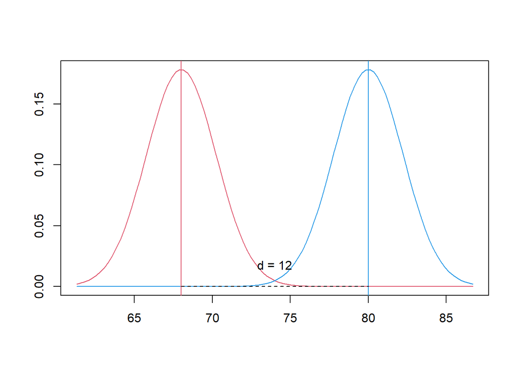

```r
plot.dist(mreal = c(68,80),var=c(5,5))
```

## Cambie los valores de las medias reales.

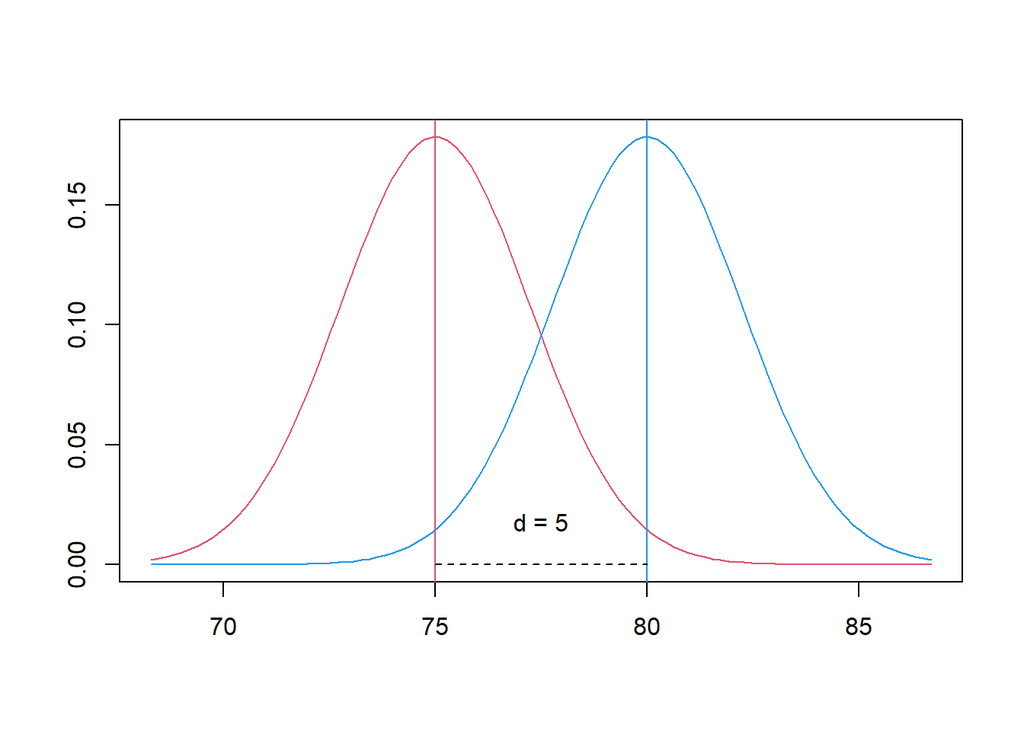

```r
plot.dist(mreal = c(75,80),var=c(5,5))
```

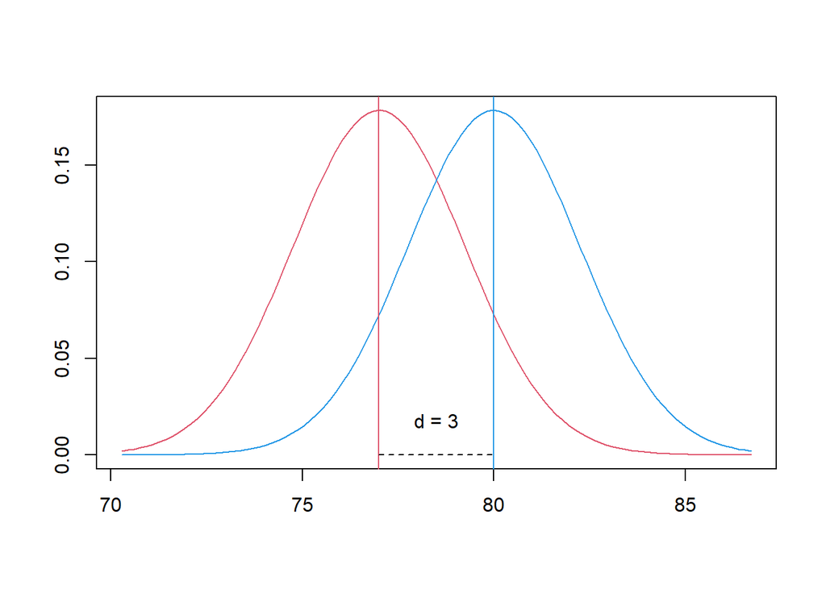

```r
plot.dist(mreal = c(77,80),var=c(5,5))
```

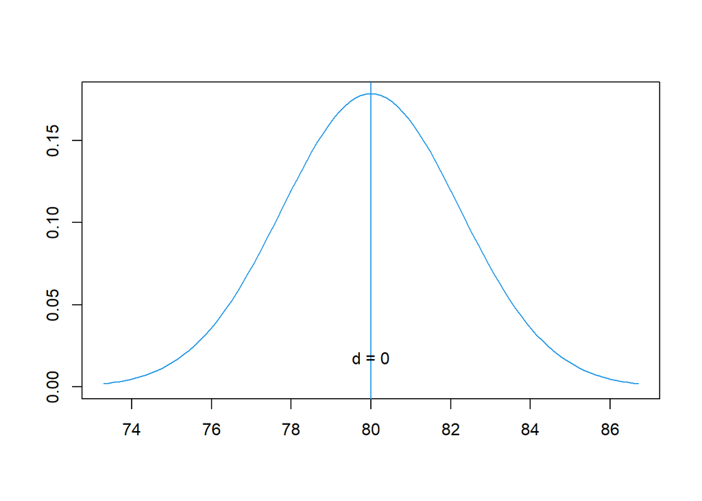

```r
plot.dist(mreal = c(80,80),var=c(5,5))
```

Cada vez es más difícil observar las diferencias entre ambas distribuciones.

## Determine un punto donde las distribuciones están tan cerca que realmente no importa tanto la separación.

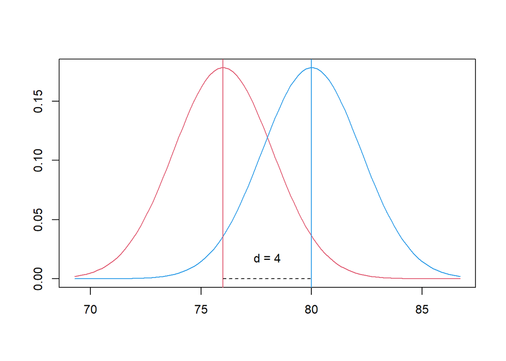

```r
plot.dist(mreal = c(76,80),var=c(5,5))
```

Se podría decir que a partir de una distancia de 4 ya las distribuciones están lo suficientemente cerca como para que una diferencia no sea tan importante. Vemos que las colas y parte de las distribuciones se traslapan entre sí.

## Repita el ejercicio anterior pero ahora mantenga la separación constante y cambie la variancia

Voy a utilizar una separación de 5

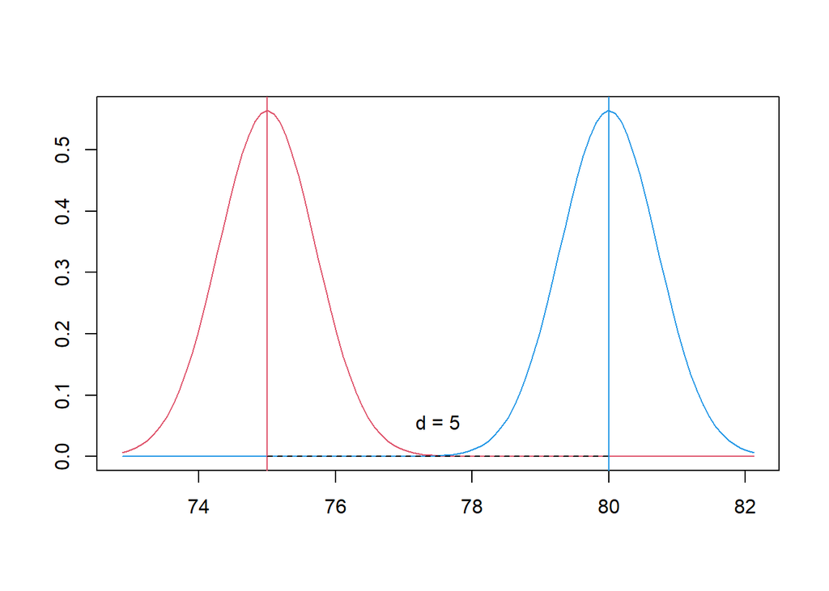

```r
plot.dist(mreal = c(75,80),var=c(0.5,0.5))
```

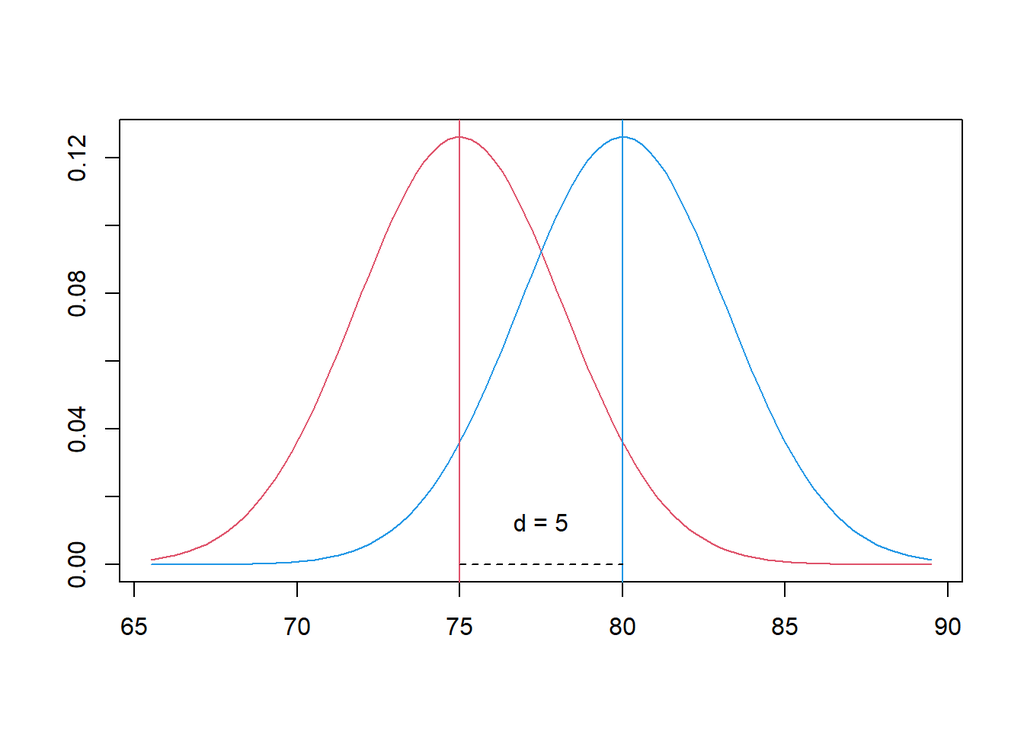

```r
plot.dist(mreal = c(75,80),var=c(10,10))
```

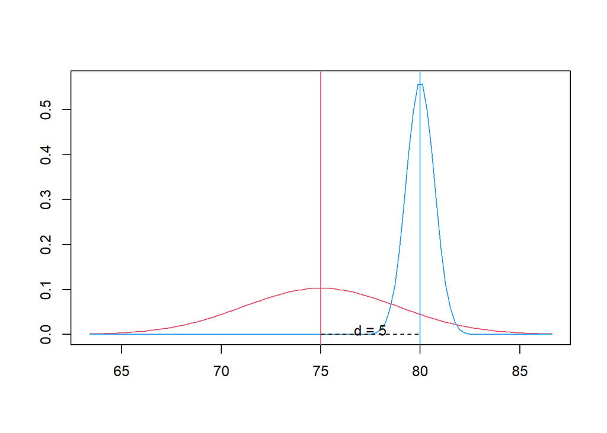

```r
plot.dist(mreal = c(75,80),var=c(15,0.5))
```

Vemos tres casos, con varianzas iguales pero bajas, iguales pero altas y una baja y una muy alta.

Observamos que cuando hay al menos una varianza muy alta es más difícil distinguir entre una distribución y otra.

## Busque un caso real y determine un punto de corte a partir del cual las distribuciones se separan una distancia que tenga sentido práctico

Caso jugadores de fútbol:

En el FC Barcelona existen dos jugadores con una cantidad similar de goles anotados en una cantidad de partidos similares, si dividimos estos goles etre los partidos jugados tenemos el promedio de gol.

- Jugador A: 29 partidos jugados, 4 goles
- Jugador B: 23 partidos jugados, 6 goles

*Datos de la Web Oficial de la Liga española de fútbol.*

Para saber qué tanta diferencia real hay, es necesario observar las desviaciones estándar

```r
4/29
```

```
## [1] 0.137931
```

```r
6/23
```

```
## [1] 0.2608696
```

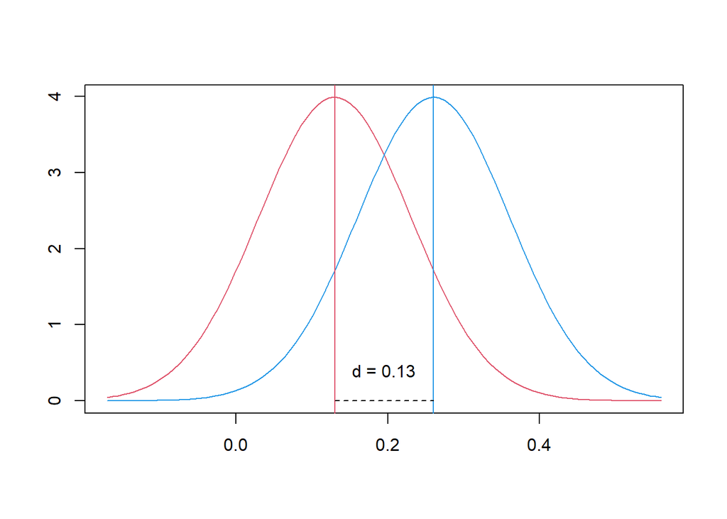

```r
plot.dist(mreal = c(0.13,0.26),var=c(0.01,0.01))
```

Vemos con esos promedios si la desviación estándar es baja, no hay mucha diferencia.

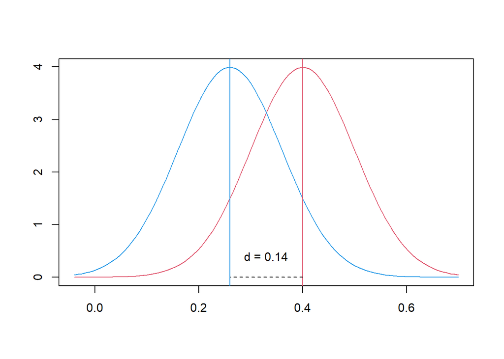

```r
plot.dist(mreal = c(0.4,0.26),var=c(0.01,0.01))
```

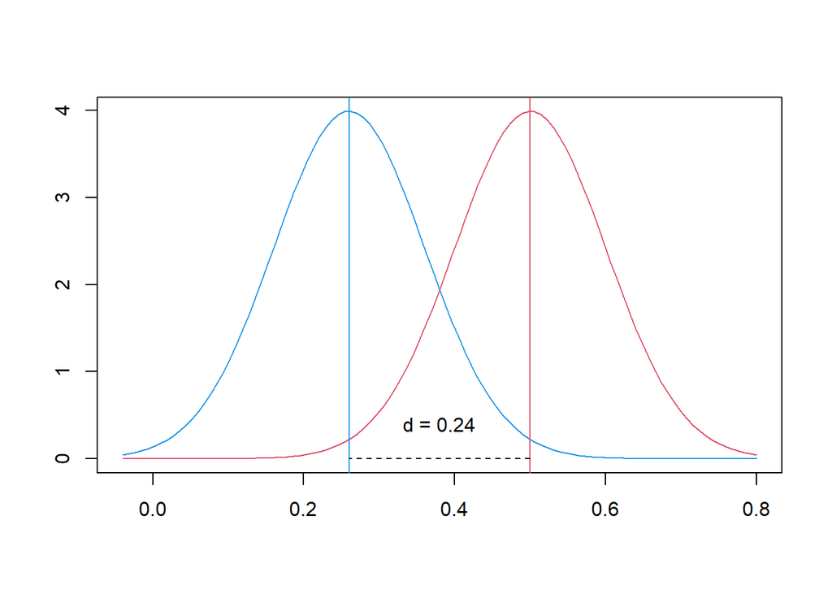

```r
plot.dist(mreal = c(0.5,0.26),var=c(0.01,0.01))
```

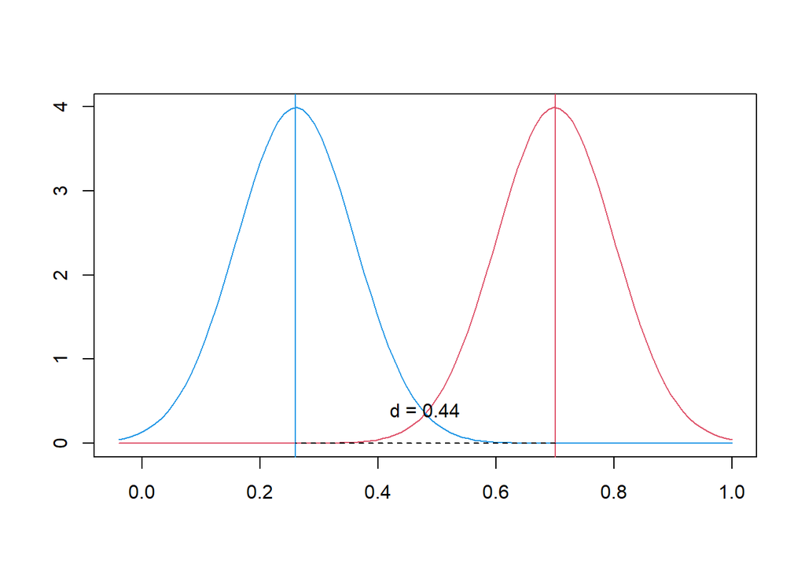

```r
plot.dist(mreal = c(0.7,0.26),var=c(0.01,0.01))
```

Pero por ejemplo, a partir de los 0.7 goles por partido, comparandolo con los 0.26 del otro jugador, el mismo tiene un promedio y una distribución significativamente más altos que el otro.

En este caso al entrenador tal vez le convenga aprovechar más al jugador que anota más o bien enfocarse en el que anota menos para que mejore y tener un mejor equipo.

# Distribuciones condicionales.

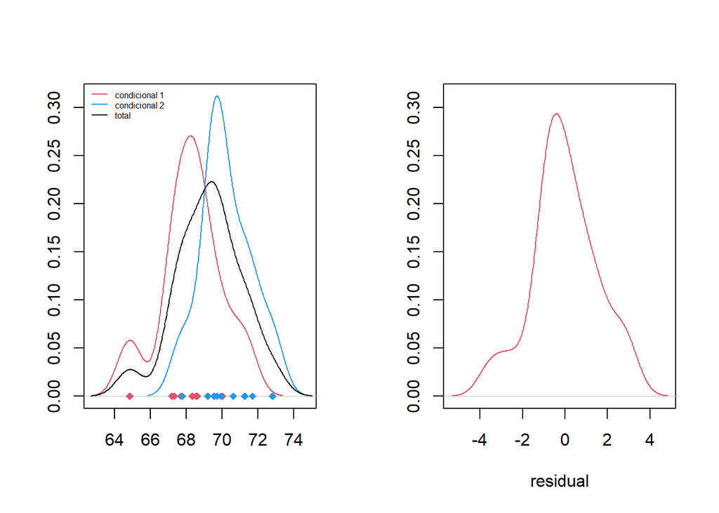

```r
plot.muestra(mreal = c(68,70),var = c(5,5),r1=10,r2=10)
```

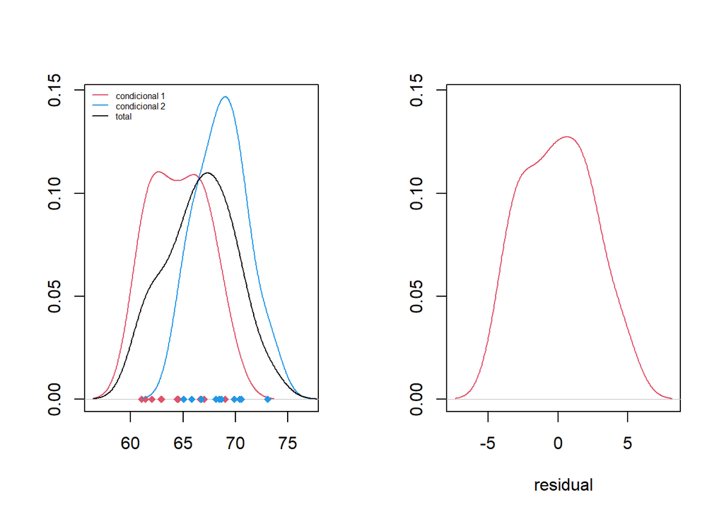

```r
plot.muestra(mreal = c(65,70),var = c(5,5),r1=10,r2=10)
```

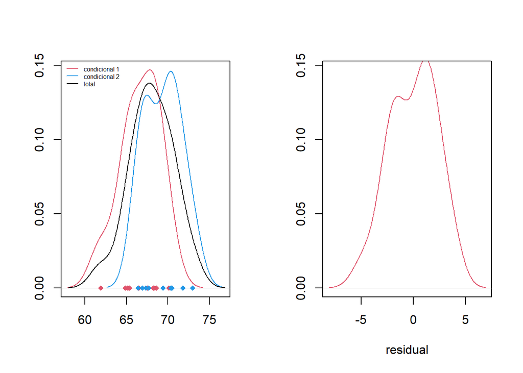

```r
plot.muestra(mreal = c(67,70),var = c(5,5),r1=10,r2=10)
```

## ¿A qué nos referimos cuando hablamos de distribución condicional?

Nos referimos a, como su nombre lo indica, a distribuciones de probabilidad o eventos que ocurren bajo alguna determinado evento o *condición*, por ejemplo podría ser la porbabilidad de X dado que Y es falso podría ser diferente a la probabilidad de X dado que Y es verdadero.

## Es tan importante la distribución total como las condicionales?

Por supuesto depende de lo que se quiera ver, pero observando los gráficos podemos inferir que la distribución total nos da información relevante sobre como se comportan los datos como un todo y no solo bajo algunas condiciones o elementos concretos.

## ¿Qué implicaciones tiene esto cuando se trata de verificar la distribución de los datos?

Cuando se verifican los datos debemos tomar en cuenta ambas distribuciones para tomar decisiones más adecuadas y llegar a conclusiones correctas, si lo ignoramos estamos omitiendo información lo cual podría ser un problema para nuestro estudio.